# RR_Proj1

Amit Chitnis

May 12, 2016

```r
        #Code for reading in the dataset and/ord processing the data
        data = read.csv("./activity.csv")
        data$date = as.Date(as.character(data$date), "%Y-%m-%d")
```

### Histogram of the total number of steps taken each day?

The code snippet below creates the histogram of the total number of steps taken each day. Additionally a line is added to the histogram to indicate the mean value. Base plotting is library is used to plot the histogram and the tapply function is used to calcualte the total number of steps.

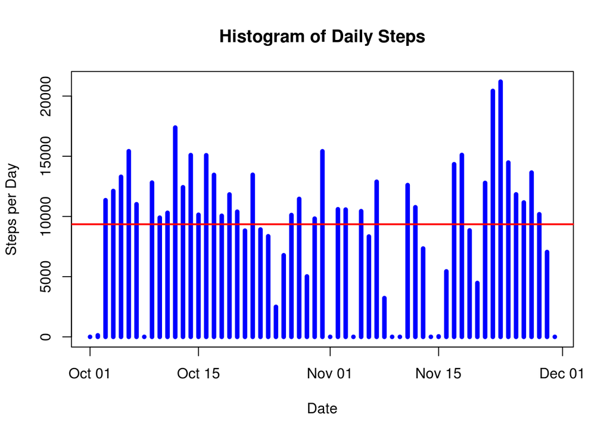

```r
        df = data
        stepsPerDay <- with(df, tapply(steps, date, sum, na.rm = T));
        df <- data.frame(date = names(stepsPerDay), total = stepsPerDay)
        df$date = as.Date(as.character(df$date), "%Y-%m-%d")
        df$total = as.numeric(df$total)


        #Histogram of the total number of steps taken each day
        plot(x = df$date, df$total, type="h", main="Histogram of Daily Steps", xlab="Date", ylab="Steps per Day", col="blue", lwd=5)
        abline(h=mean(df$total, na.rm=TRUE), col="red", lwd=2)
```

### Mean and median number of steps taken each day NA values are ignored while calcualting Mean and Median values of the dataset.

```r
paste(("Mean number of steps taken each day:"), round(mean(df$total, na.rm = TRUE)))
```

```
## [1] "Mean number of steps taken each day: 9354"
```

```r
paste(("Median of number of steps taken each day:"), round(mean(df$total, na.rm = TRUE)))
```

[output not shown]

### Time series plot of the average number of steps taken

The code snippet below plots the time series plot of the average number of steps taken during each 5-minute interval. Base plotting library is used to plot the graph and tapply function is used to calculate the mean number of steps. A line is added to the plot to indicate the mean value.

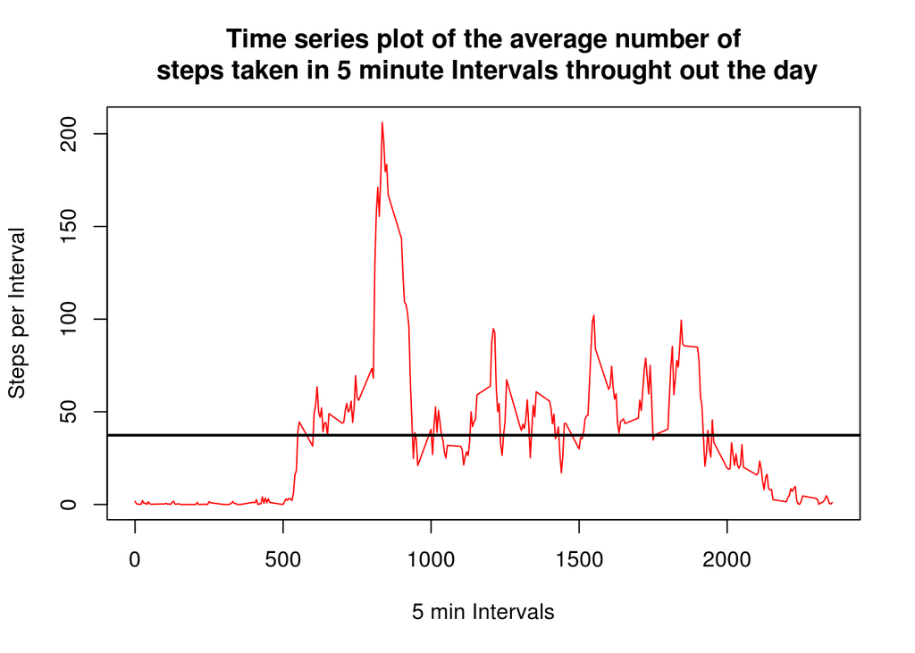

```r
#Time series plot of the average number of steps taken
        dfMnStpsPerInt= data
        stepsPerInterval <- with(dfMnStpsPerInt, tapply(steps, interval, mean, na.rm = T));
        dfMnStpsPerInt <- data.frame(interval = unique(dfMnStpsPerInt$interval), mean = stepsPerInterval);
        plot(x = dfMnStpsPerInt$interval, dfMnStpsPerInt$mean, type="l", main="Time series plot of the average number of\n steps taken in 5 minute Intervals throught out the day", xlab="5 min Intervals", ylab="Steps per Interval", col="red")
        abline(h=mean(dfMnStpsPerInt$mean, na.rm=TRUE), col="black", lwd=2)
```

###The 5-minute interval that, on average, contains the maximum number of steps

```r
paste("Interval with max value =", dfMnStpsPerInt$interval[which(dfMnStpsPerInt$mean == max(dfMnStpsPerInt$mean))])
```

```
## [1] "Interval with max value = 835"
```

### Code to describe and show a strategy for imputing missing data

I have decided to replace NA values for a given time interval with the mean value for that time interval. The following code snippet adds the missing values to the dataset by using the mean values dataset created in the previous steps. The entire data set is looped through to replace the NA values with the mean values. NA checks are done prior and after to validate the that NA values are truly removed.

```r
#Calculate and report the total number of missing values in the dataset (i.e. the total number of rows with NAs)
sum(is.na(data$steps))
```

```
## [1] 2304
```

```r
#Use Mean values per interval to replace missing values
dataImputed = data
for (i in 1:nrow(dataImputed)){
        if (is.na(dataImputed[i,"steps"])){
                dataImputed[i, "steps"] = dfMnStpsPerInt$mean[which(dfMnStpsPerInt$interval == dataImputed[i, "interval"])];
        }
}
sum(is.na(dataImputed$steps))
```

```
## [1] 0
```

### Histogram of the total number of steps taken each day after missing values are imputed

The code snippet in the first step is reused after updating the variable names. Mean and Median values increase after imputation.

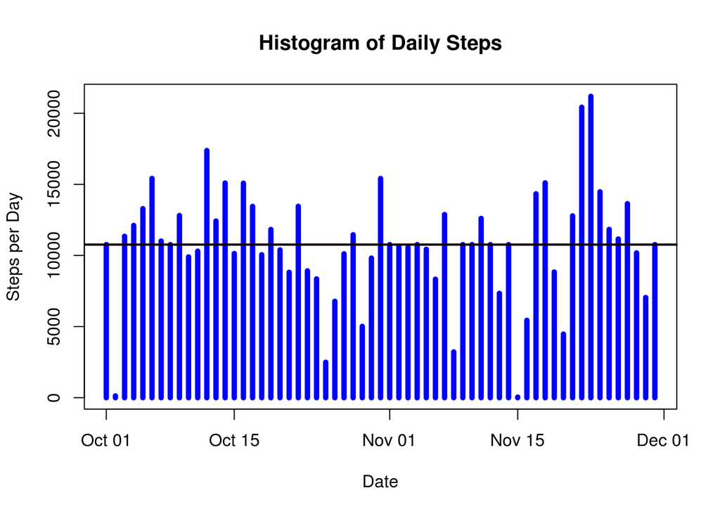

```r
stepsPerDay <- with(dataImputed, tapply(steps, date, sum, na.rm = T));
dfImputed <- data.frame(date = names(stepsPerDay), total = stepsPerDay)
dfImputed$date = as.Date(as.character(dfImputed$date), "%Y-%m-%d")
dfImputed$total = as.numeric(dfImputed$total)

#Histogram of the total number of steps taken each day
plot(x = dfImputed$date, dfImputed$total, type="h", main="Histogram of Daily Steps", xlab="Date", ylab="Steps per Day", col="blue", lwd=5)
abline(h=mean(dfImputed$total, na.rm=TRUE), col="red", lwd=2)
abline(h=median(dfImputed$total, na.rm=TRUE), col="black", lwd=2)
```

```r
#Mean and median number of steps taken each day
paste(("Mean number of steps taken each day after imputation:"), round(mean(dfImputed$total)))
```

```
## [1] "Mean number of steps taken each day after imputation: 10766"
```

```r
paste(("Median of number of steps taken each day after imputation:"), round(mean(dfImputed$total)))
```

[output not shown]

#### Are there differences in activity patterns between weekdays and weekends

A new column “DayOftheWeek” is added to store factor variable weekday or weekend. Again the entire data set is looped through to determine weekday using “weekdays()” function.

```r
dataImputed["DayOftheWeek"] <- NA;
for (i in 1:nrow(dataImputed)){
        dataImputed[i, "DayOftheWeek" ] <- weekdays(dataImputed[i, "date"])
        if(dataImputed[i,"DayOftheWeek" ] == "Saturday" | dataImputed[i,"DayOftheWeek" ] == "Sunday"){
                dataImputed[i,"DayOftheWeek" ] = "weekend"
        }
        else {
                dataImputed[i,"DayOftheWeek" ] = "weekday"
        }

}
```

### Panel plot comparing the average number of steps taken per 5-minute interval across weekdays and weekends

As before base plotting library is used to plot timeseries for weekdays and weekends.

[figure not shown]

```r
dfImputedMnStpsPerIntWd <- subset(dataImputed, DayOftheWeek == "weekday")
stepsPerInterval <- with(dfImputedMnStpsPerIntWd, tapply(steps, interval , mean, na.rm = T))
dfImputedMnStpsPerIntWd <- data.frame(interval = unique(dfImputedMnStpsPerIntWd$interval), mean = stepsPerInterval);

dfImputedMnStpsPerIntWE <- subset(dataImputed, DayOftheWeek == "weekend")
stepsPerInterval <- with(dfImputedMnStpsPerIntWE, tapply(steps, interval , mean, na.rm = T))
dfImputedMnStpsPerIntWE <- data.frame(interval = unique(dfImputedMnStpsPerIntWE$interval), mean = stepsPerInterval);


par(mfrow=c(2,1))
plot(x = dfImputedMnStpsPerIntWd$interval, dfImputedMnStpsPerIntWd$mean, type="l", main="Time series plot of the average number of\n steps taken in 5 minute Intervals on weekdays", xlab="5 min Intervals", ylab="Steps per Interval", col="red")
plot(x = dfImputedMnStpsPerIntWE$interval, dfImputedMnStpsPerIntWE$mean, type="l", main="Time series plot of the average number of\n steps taken in 5 minute Intervals on weekdays", xlab="5 min Intervals", ylab="Steps per Interval", col="red")
```